# Tyler Rinker

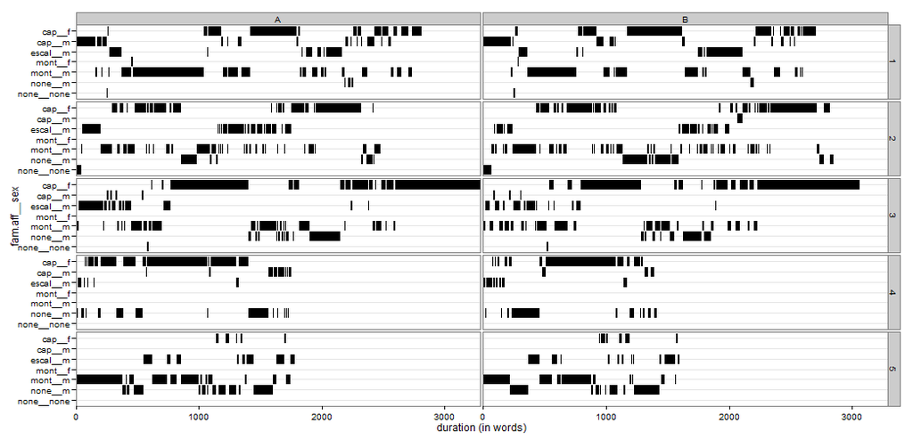

```r
z + scale_colour_manual(values=rep("black", 7))
```

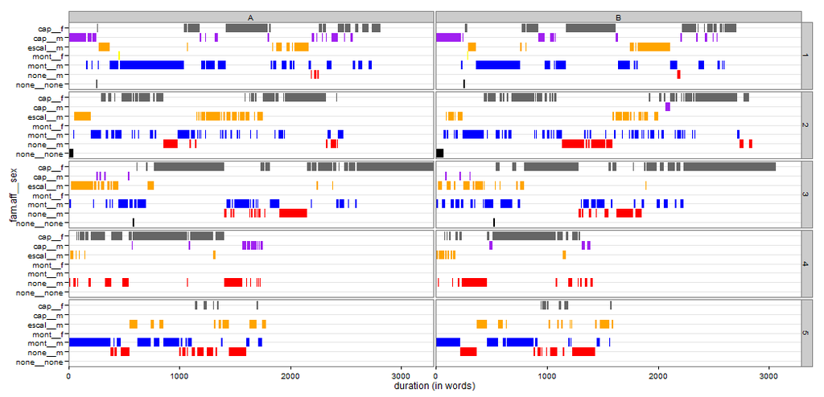

```r
## vector of colors
cols <- c("black", "red", "blue", "yellow", "orange", "purple", "grey40")

z + scale_colour_manual(values=cols)
```

At times it may be useful to fill the bar colors by another grouping variable. The **fill.var** argument allows another coloring variable to be utilized.

♦ **[`gantt_plot`](http://trinker.github.io/qdap_dev/gantt_plot.html)** - *Fill Variable Example 1*♦

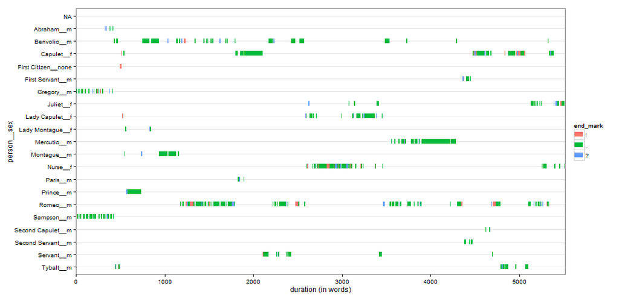

```r
## Generate an end mark variable set to fill by
dat <- rajSPLIT[rajSPLIT$act == 1, ]
dat$end_mark <- factor(end_mark(dat$dialogue))

with(dat, gantt_plot(text.var = dialogue, grouping.var = list(person, sex),
    fill.var=end_mark))
```

♦ **[`gantt_plot`](http://trinker.github.io/qdap_dev/gantt_plot.html)** - *Fill Variable Example 2*♦

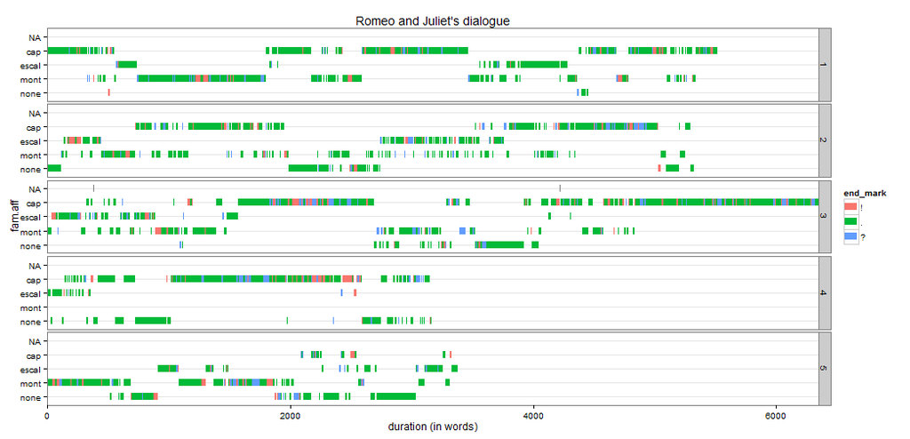

```r
## Generate an end mark variable data set to fill by
rajSPLIT2 <- rajSPLIT
rajSPLIT2$end_mark <- end_mark(rajSPLIT2$dialogue)

with(rajSPLIT2, gantt_plot(text.var = dialogue,
    grouping.var = list(fam.aff), rm.var  = list(act),
    fill.var=end_mark, title = "Romeo and Juliet's dialogue"))
```

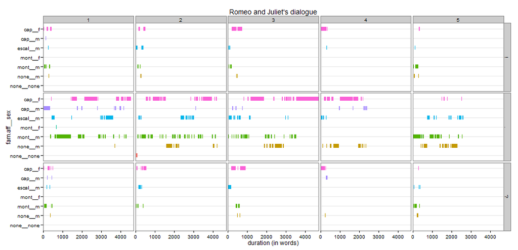

```r
## Repeated Measures Sentence Type Example
with(rajSPLIT2, gantt_plot(text.var = dialogue,
    grouping.var = list(fam.aff, sex), rm.var  = list(end_mark, act),
    title = "Romeo and Juliet's dialogue"))
```

#### Quick Heatmap

Heatmaps are a powerful way to visualize patterns in matrices. The gradient allows the user to quickly pick out high and low values. [`qheat`](http://trinker.github.io/qdap_dev/qheat.html) (quick heat map) is a heat map function that accepts matrices and dataframes and has some nice pre-sets that work well with the way qdap data is structured. Two of these assumptions to be aware of is that dataframe is numeric with the exception of a single grouping variable column with the possibility of additional non-numeric columns passed to **facet.vars**. [`qheat`](http://trinker.github.io/qdap_dev/qheat.html) also assumes that matrices are all numeric with row names serving as the grouping variable. If passing a dataframe, [`qheat`](http://trinker.github.io/qdap_dev/qheat.html) the grouping variable column is assumed to be the first column.

The following examples demonstrate various uses of [`qheat`](http://trinker.github.io/qdap_dev/qheat.html).

♦ **[`qheat`](http://trinker.github.io/qdap_dev/qheat.html)** - *Basic Example*♦

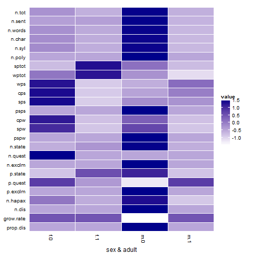

```r
## word stats data set
ws.ob <- with(DATA.SPLIT, word_stats(state, list(sex, adult), tot=tot))

# same as `plot(ws.ob)`
qheat(ws.ob)
```

♦ **[`qheat`](http://trinker.github.io/qdap_dev/qheat.html)** - *Color Group Labels Example*♦

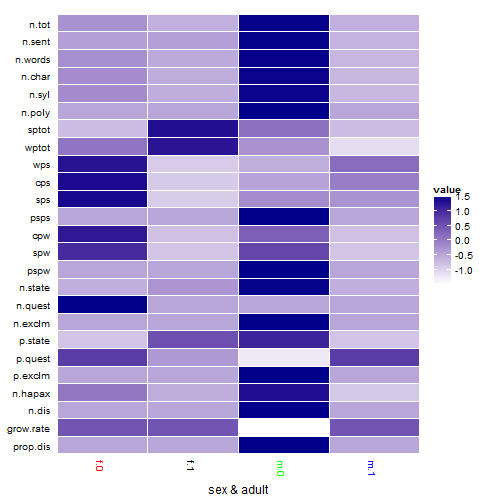

```r
qheat(ws.ob, xaxis.col = c("red", "black", "green", "blue"))
```

♦ **[`qheat`](http://trinker.github.io/qdap_dev/qheat.html)** - *Order By Numeric Variable Examples*♦

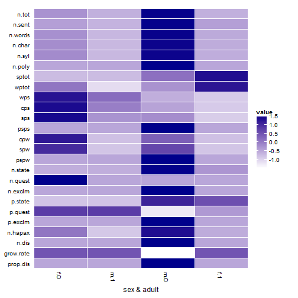

```r
## Order by sptot
qheat(ws.ob, order.by = "sptot")
```

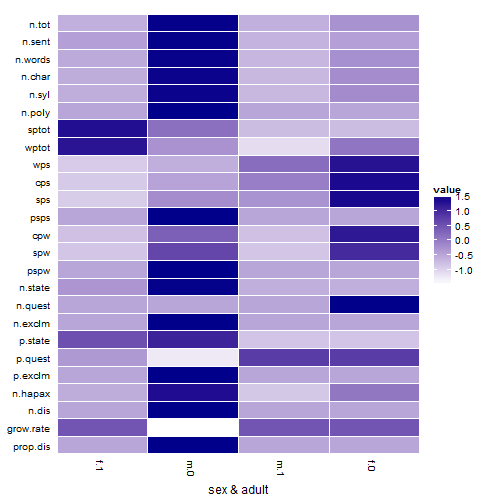

```r
## Reverse order by sptot
qheat(ws.ob, order.by = "-sptot")
```

♦ **[`qheat`](http://trinker.github.io/qdap_dev/qheat.html)** - *Cell Labels Examples*♦

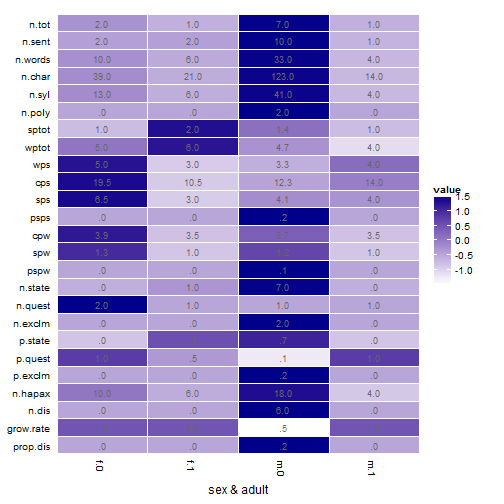

```r
qheat(ws.ob, values = TRUE)
```

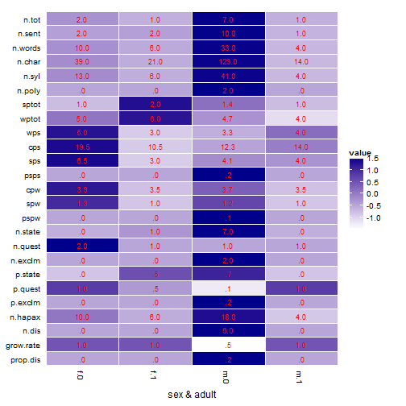

```r
qheat(ws.ob, values = TRUE, text.color = "red")
```

♦ **[`qheat`](http://trinker.github.io/qdap_dev/qheat.html)** - *Custom Cell Labels Example*♦

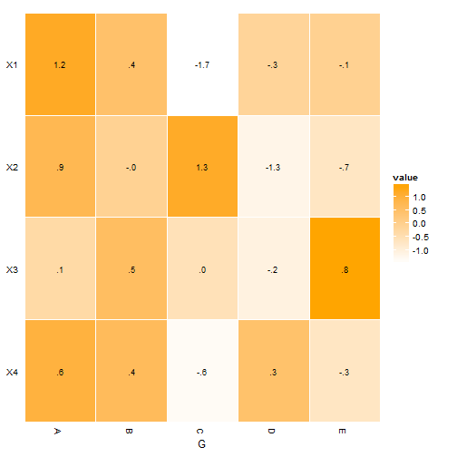

```r
## Create a data set and matching labels
dat1 <- data.frame(G=LETTERS[1:5], matrix(rnorm(20), ncol = 4))
dat2 <- data.frame(matrix(LETTERS[1:25], ncol=5))
qheat(dat1, high = "orange", values=TRUE, text.color = "black")
```

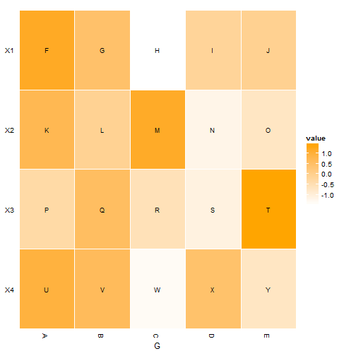

```r
qheat(dat1, high = "orange", values=TRUE, text.color = "black", mat2=dat2)
```

♦ **[`qheat`](http://trinker.github.io/qdap_dev/qheat.html)** - *Grid Examples*♦

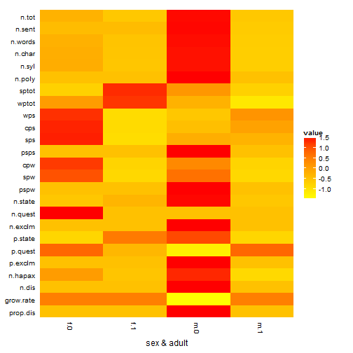

```r
qheat(ws.ob, "yellow", "red", grid = FALSE)
```

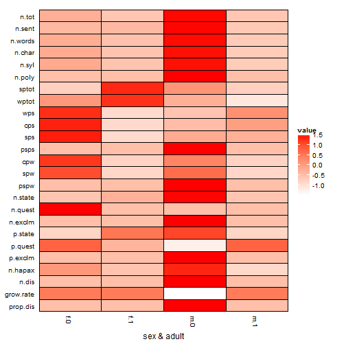

```r
qheat(ws.ob, high = "red", grid = "black")
```

♦ **[`qheat`](http://trinker.github.io/qdap_dev/qheat.html)** - *Facet Examples*♦

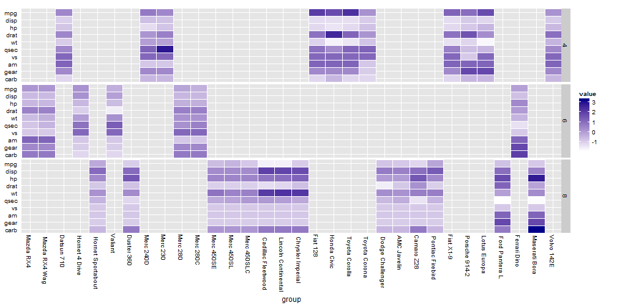

```r
qheat(mtcars, facet.vars = "cyl")
```

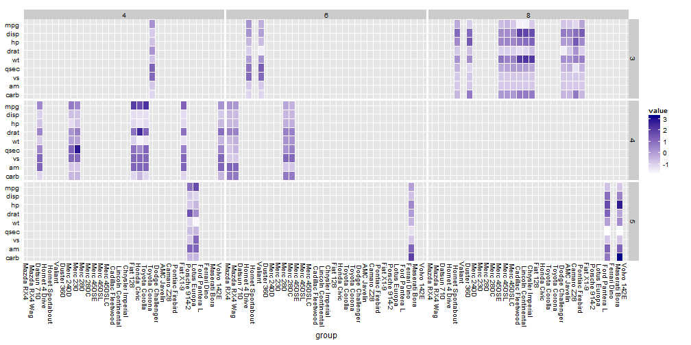

```r
qheat(mtcars, facet.vars = c("gear", "cyl"))
```

♦ **[`qheat`](http://trinker.github.io/qdap_dev/qheat.html)** - *Transposing Examples*♦

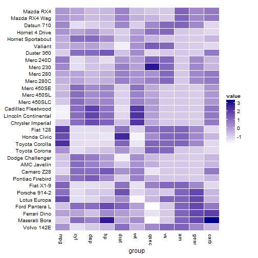

```r
qheat(t(mtcars), by.column=FALSE)
```

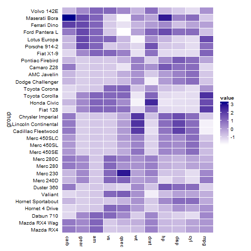

```r
qheat(mtcars, plot = FALSE) + coord_flip()
```

When plotting a correlation/distance matrix set **diag.na = TRUE** to keep these extreme values from effecting the scaling.

♦ **[`qheat`](http://trinker.github.io/qdap_dev/qheat.html)** - *Correlation Matrix Examples*♦

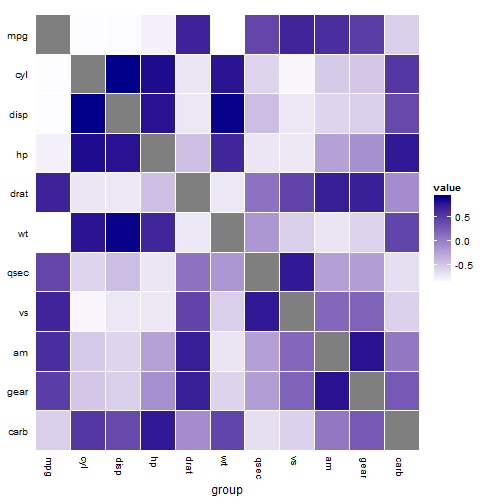

```r
qheat(cor(mtcars), diag.na=TRUE, by.column = NULL)
```

#### Rank Frequency Plot

Rank Frequency Plots are a way of visualizing word rank versus frequencies as related to Zipf's law which states that the rank of a word is inversely related to its frequency. The [`rank_freq_mplot`](http://trinker.github.io/qdap_dev/rank_freq_mplot.html) and [`rank_freq_plot`](http://trinker.github.io/qdap_dev/rank_freq_mplot.html) provide the means to plot the ranks and frequencies of words (with [`rank_freq_mplot`](http://trinker.github.io/qdap_dev/rank_freq_mplot.html) plotting by grouping variable(s)).

[`rank_freq_mplot`](http://trinker.github.io/qdap_dev/rank_freq_mplot.html) utilizes the ggplot2 package, whereas, [`rank_freq_plot`](http://trinker.github.io/qdap_dev/rank_freq_mplot.html) employs base graphics. [`rank_freq_mplot`](http://trinker.github.io/qdap_dev/rank_freq_mplot.html) is more general, flexible, and takes text/grouping variables directly; in most cases [`rank_freq_mplot`](http://trinker.github.io/qdap_dev/rank_freq_mplot.html) should be preferred (though [`rank_freq_plot`](http://trinker.github.io/qdap_dev/rank_freq_mplot.html) will render quicker). The [`rank_freq_mplot`](http://trinker.github.io/qdap_dev/rank_freq_mplot.html) family of functions also outputs a list of rank/frequency dataframes used plot the visuals and other related descriptive statistics.

♦ **[`rank_freq_mplot`](http://trinker.github.io/qdap_dev/rank_freq_mplot.html)**♦

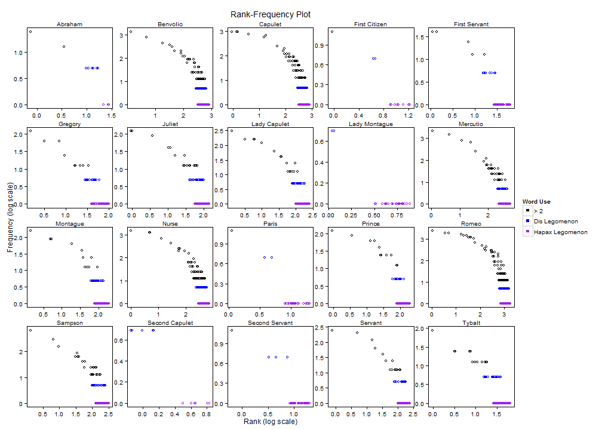

```r
## Plot log-log version
x2 <- rank_freq_mplot(mraja1spl$dialogue, mraja1spl$person, ncol = 5,
    hap.col = "purple")
```

```r
## View output
ltruncdf(x2, 10)
```

```
## $WORD_COUNTS
##      group   word freq
## 1  Abraham    sir    4
## 2  Abraham    you    3
## 3  Abraham     at    2
## 4  Abraham   bite    2
## 5  Abraham     do    2
## 6  Abraham     no    2
## 7  Abraham  thumb    2
## 8  Abraham     us    2
## 9  Abraham   your    2
## 10 Abraham better    1
##
## $RANK_AND_FREQUENCY_STATS
##       group n.words freq rank
```

[output cut: 23 more lines]

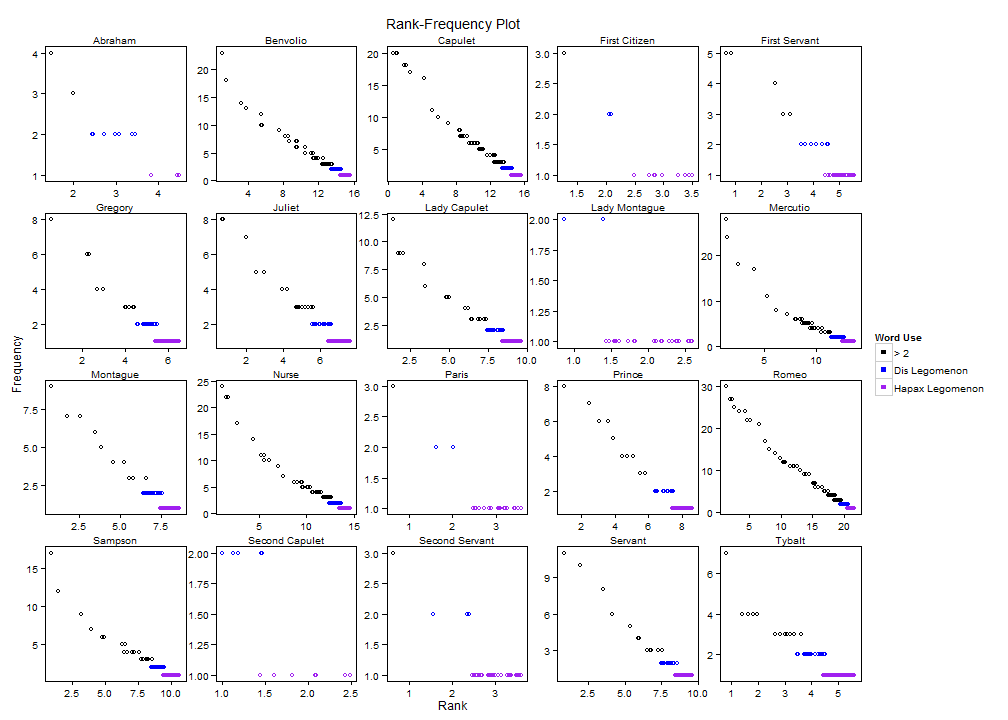

```r
## Plot standard rank-freq version
invisible(rank_freq_mplot(mraja1spl$dialogue, mraja1spl$person, ncol = 5,
    log.freq = FALSE, log.rank = FALSE, jitter = .6,  hap.col = "purple"))
```

♦ **[`rank_freq_mplot`](http://trinker.github.io/qdap_dev/rank_freq_mplot.html)** - *Using alpha*♦

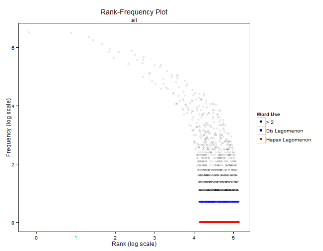

```r
invisible(rank_freq_mplot(raj$dialogue, jitter = .5, shape = 19, alpha = 1/15))
```

The [`rank_freq_plot`](http://trinker.github.io/qdap_dev/rank_freq_mplot.html) plots more quickly but does not handle multiple groups and does not take text/grouping variables directly.

♦ **[`rank_freq_plot`](http://trinker.github.io/qdap_dev/rank_freq_mplot.html) Example** ♦

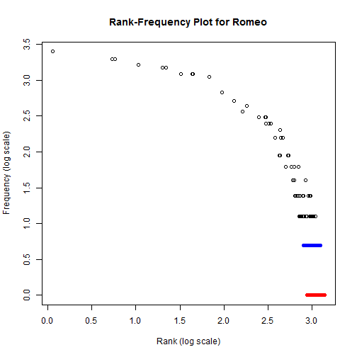

```r
## Generate data for `rank_freq_plot` via `word_list` function
mod <- with(mraja1spl , word_list(dialogue, person, cut.n = 10,
    cap.list=unique(mraja1spl$person)))

## Plot it
x3 <- rank_freq_plot(mod$fwl$Romeo$WORD, mod$fwl$Romeo$FREQ,
    title.ext = 'Romeo')
```

```r
## View output
ltruncdf(x3, 10)
```

```
## $WORD_COUNTS
##    words freq
## 1      I   30
## 2      a   27
## 3    the   27
## 4    and   25
## 5     is   24
## 6     of   24
## 7     my   22
## 8   that   22
## 9     to   22
## 10    in   21
##
## $RANK_AND_FREQUENCY_STATS
##    n.words freq rank per.of.tot
## 1        1   30    1      2.591
## 2        2   27    2      2.332
## 3        1   25    3      2.159
## 4        2   24    4      2.073
## 5        3   22    5        1.9
## 6        1   21    6      1.813
## 7        1   17    7      1.468
## 8        1   15    8      1.295
## 9        1   14    9      1.209
## 10       1   13   10      1.123
##
## $LEGOMENA_STATS
##   dataframe
## 1    69.143
## 2        16
```

#### Visualize Word Length by Turn of Talk

It is often useful to view the lengths of turns of talk as a bar plot, particularly if the bars are colored by grouping variable. The [`tot_plot`](http://trinker.github.io/qdap_dev/tot_plot.html) function plots dialogue as a bar plot with the option to color by grouping variables and facet by repeated measure variables. This can enable the entire dialogue to be viewed in a succinct way, possibly leading the researcher to see patterns that may have otherwise escaped attention.

Within the [`tot_plot`](http://trinker.github.io/qdap_dev/tot_plot.html) function the turn of talk argument (**tot**) may be the **“tot”** column from [`sentSplit`](http://trinker.github.io/qdap_dev/sentSplit.html) output (**tot = TRUE**), the row numbers (**tot = FALSE**), the character name of a column (**tot = “COLUMN NAME”**), or a separate numeric/character vector equal in length to the **text.var**.

♦ **[`tot_plot`](http://trinker.github.io/qdap_dev/tot_plot.html)** - *Examples* ♦

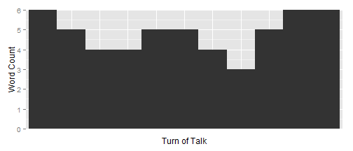

```r
dataframe <- sentSplit(DATA, "state")
tot_plot(dataframe, text.var = "state")
```

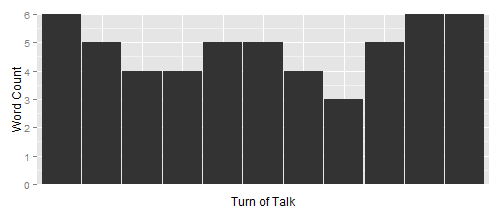

```r
## Change space between bars
tot_plot(dataframe, text.var = "state", bar.space = .03)
```

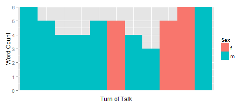

```r
## Color bars by grouping variable(s)
tot_plot(dataframe, text.var = "state", grouping.var = "sex")
```

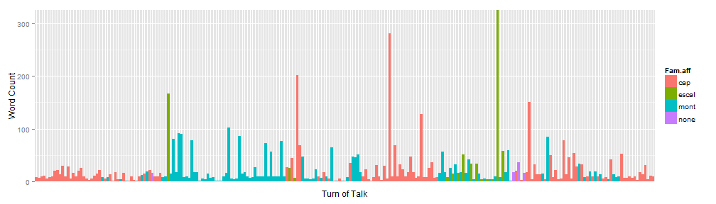

```r
## Use rownames as tot: color by family affiliation
tot_plot(mraja1, "dialogue", grouping.var = "fam.aff", tot = FALSE)
```

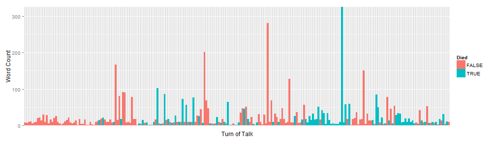

```r
## Use rownames as tot: color by death
tot_plot(mraja1, "dialogue", grouping.var = "died", tot = FALSE)
```

♦ **[`tot_plot`](http://trinker.github.io/qdap_dev/tot_plot.html)** - *Facet Variables* ♦

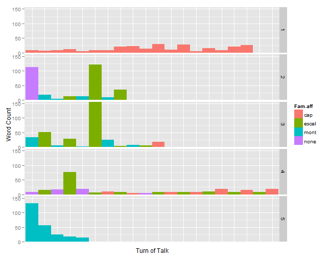

```r
rajSPLIT2 <- do.call(rbind, lapply(split(rajSPLIT, rajSPLIT$act), head, 25))
tot_plot(rajSPLIT2, "dialogue", grouping.var = "fam.aff", facet.var = "act")
```

Because [`tot_plot`](http://trinker.github.io/qdap_dev/tot_plot.html) is based on the [ggplot2 package](http://docs.ggplot2.org/current/) (Wickham, 2009) and [`tot_plot`](http://trinker.github.io/qdap_dev/tot_plot.html) invisibly returns the ggplot2 object, the output (of the class “ggplot”) can be altered in the same way that another ggplot2 object can be. In the following examples the color palette is altered.